# Researching The Right Thing

### Assessing the Practical Relevance of Requirements Engineering Research

#### Corinna Coupette

### Agenda

1. Background
2. Results
3. Discussion

### 1. Background

[figure not shown]

#### The RE-Pract Survey Research Questions

1. What is the relevance of RE research to practitioners in the industry?
2. What are the most highly rated research ideas?
3. What research problems do practitioners think are most important to be focused on by the RE research community?
4. Do papers with explicit ties to industry have higher practical relevance than other papers?
5. Do practitioners’ perceptions and views differ in dependence on their roles?

#### Our Data Sources

- 435 Paper Summaries with Metadata and Tags
- 154 Respondents with Metadata
- 2164 Paper Ratings

## 2. Results

### Setup

```python
%run setup.py
%matplotlib inline
```

### The Respondents

```python
dfdict['truth_metadata'].head(3)
```

|  | lfdn | lfdn_original | v_5 | v_6 | v_11 | v_118 | v_119 | v_120 | v_121 | v_12 | v_14 | v_15 | v_16 | v_19 | v_124 | v_5_6_integrated | v_15_16_integrated | v_11_coded | v_19_coded |
| --- | --- | --- | --- | --- | --- | --- | --- | --- | --- | --- | --- | --- | --- | --- | --- | --- | --- | --- | --- |
| 0 | 0 | 106 | Other (please specify) | Researcher | 4 | not quoted | not quoted | quoted | not quoted | Yes | Small (1-4) | Hybrid / mix of embedded systems and informati... | NotAnswered | Automotive | Italy | Researcher | Hybrid / mix of embedded systems and informati... | 4.0 | Automotive |
| 1 | 1 | 131 | Developer | NotAnswered | 1 | quoted | not quoted | not quoted | not quoted | Yes | Medium (5-10) | (Business) information systems | NotAnswered | education | Belgium | Developer | (Business) information systems | 1.0 | Education |
| 2 | 2 | 139 | Other (please specify) | Product Management Coach | 10 | quoted | quoted | quoted | not quoted | No | Medium (5-10) | Other (please specify) | Customer facing software products | Wide range (from automotive supplier to insura... | Germany | Coach | Consumer Software | 10.0 | Multiple Sectors |

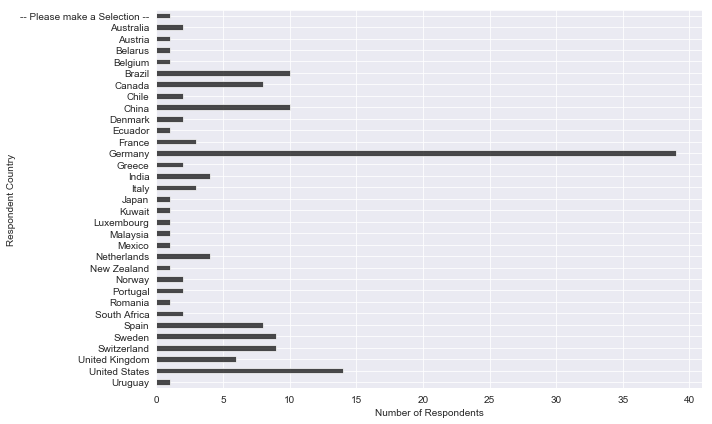

```python
plot_sample(dfdict['truth_metadata'],'v_124', 'Respondent Country')
```

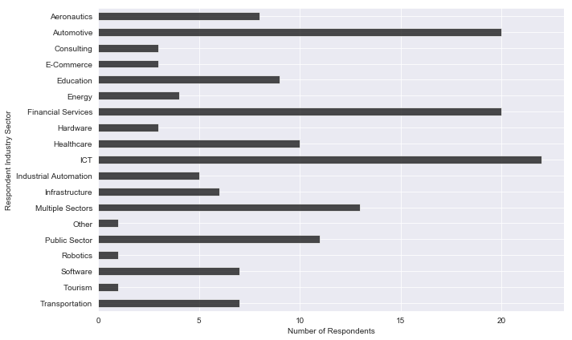

```python
plot_sample(dfdict['truth_metadata'],'v_19_coded', 'Respondent Industry Sector')
```

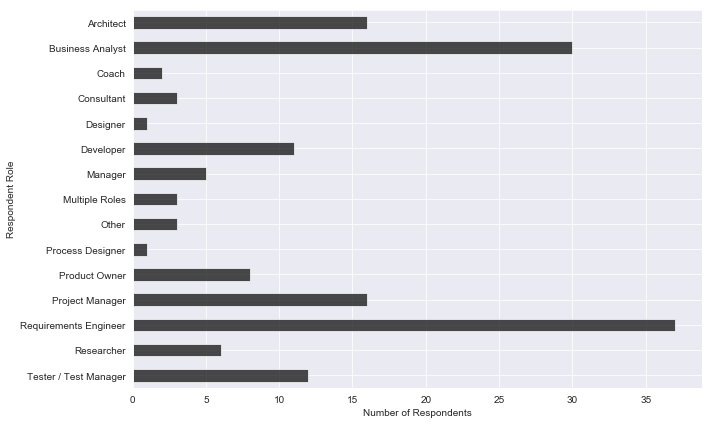

```python
plot_sample(dfdict['truth_metadata'],'v_5_6_integrated', 'Respondent Role')
```

### The Ratings

```python
ratings_with_respondent_meta.head(3)
```

|  | lfdn | PaperID | rating | lfdn_original | v_5 | v_6 | v_11 | v_118 | v_119 | v_120 | ... | v_12 | v_14 | v_15 | v_16 | v_19 | v_124 | v_5_6_integrated | v_15_16_integrated | v_11_coded | v_19_coded |
| --- | --- | --- | --- | --- | --- | --- | --- | --- | --- | --- | --- | --- | --- | --- | --- | --- | --- | --- | --- | --- | --- |
| 0 | 2 | 10 | Worthwhile | 139 | Other (please specify) | Product Management Coach | 10 | quoted | quoted | quoted | ... | No | Medium (5-10) | Other (please specify) | Customer facing software products | Wide range (from automotive supplier to insura... | Germany | Coach | Consumer Software | 10.0 | Multiple Sectors |
| 1 | 2 | 23 | Unwise | 139 | Other (please specify) | Product Management Coach | 10 | quoted | quoted | quoted | ... | No | Medium (5-10) | Other (please specify) | Customer facing software products | Wide range (from automotive supplier to insura... | Germany | Coach | Consumer Software | 10.0 | Multiple Sectors |
| 2 | 2 | 49 | Essential | 139 | Other (please specify) | Product Management Coach | 10 | quoted | quoted | quoted | ... | No | Medium (5-10) | Other (please specify) | Customer facing software products | Wide range (from automotive supplier to insura... | Germany | Coach | Consumer Software | 10.0 | Multiple Sectors |

3 rows × 21 columns

```
rating
Unwise           92
Unimportant     548
Worthwhile     1003
Essential       521
Name: lfdn, dtype: int64
```

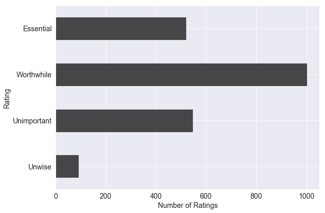

```python
x = ratings_with_respondent_meta.groupby('rating').count(
                            )['lfdn'].sort_index(ascending=False)
x.plot.barh(stacked=False,color='k', alpha=0.7)
plt.ylabel('Rating')
plt.xlabel('Number of Ratings')
plt.tight_layout()
plt.rcParams.update({'font.size': 14})
plt.rcParams['figure.figsize'] = 9, 6
plt.savefig("overallPerception.pdf")
x
```

### Ratings Grouped by Respondent Metadata

#### Example: Respondent Role

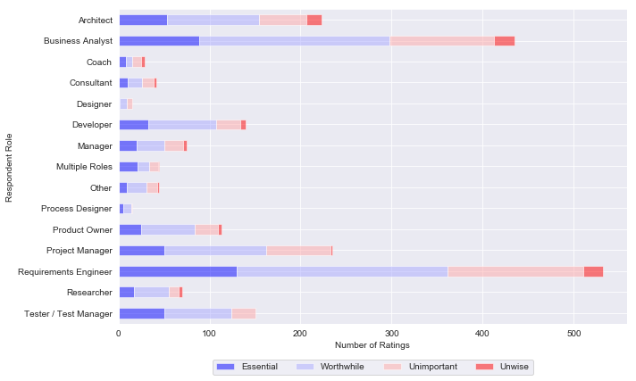

```python
plot_df(ratings_with_respondent_meta, 'v_5_6_integrated', 'Respondent Role', absolute=True)
```

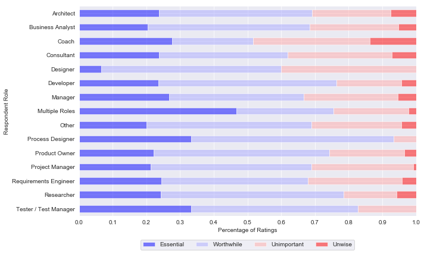

```python
plot_df(ratings_with_respondent_meta, 'v_5_6_integrated', 'Respondent Role', absolute=False)
```

### Ratings Grouped by Paper Metadata

```python
ratings_meta = dfdict['paper_metadata'].merge(dfdict['truth_ratings'], on='PaperID')
ratings_meta.head(3)
```

|  | PaperID | Title | Authors | Venue | Year | NumberOfPages | AcadVsInd | IndTrack | Summary | lfdn | rating |
| --- | --- | --- | --- | --- | --- | --- | --- | --- | --- | --- | --- |
| 0 | 1 | Software traceability with topic modeling | Hazeline U. Asuncion, Arthur U. Asuncion, Rich... | ICSE | 2010 | 10 | Academic | No | A method for automatically recovering software... | 16 | Worthwhile |
| 1 | 1 | Software traceability with topic modeling | Hazeline U. Asuncion, Arthur U. Asuncion, Rich... | ICSE | 2010 | 10 | Academic | No | A method for automatically recovering software... | 52 | Essential |
| 2 | 1 | Software traceability with topic modeling | Hazeline U. Asuncion, Arthur U. Asuncion, Rich... | ICSE | 2010 | 10 | Academic | No | A method for automatically recovering software... | 96 | Worthwhile |

#### Example: Author Affiliations and Conference Tracks

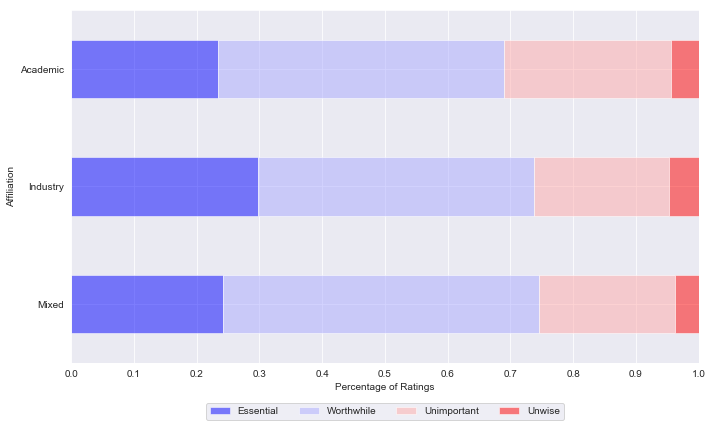

```python
plot_df(ratings_meta, 'AcadVsInd', 'Affiliation', absolute=False)
```

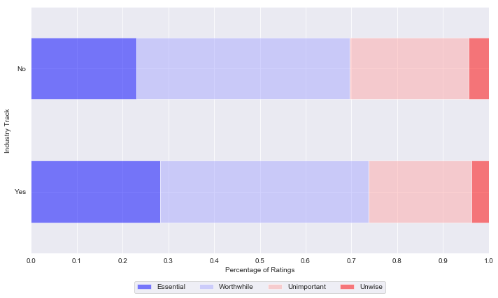

```python
plot_df(ratings_meta, 'IndTrack', 'Industry Track', absolute=False)
```

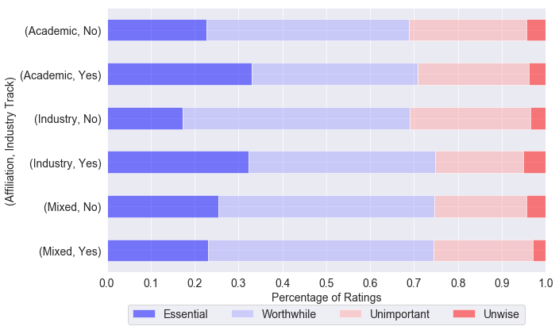

```python
plot_df(ratings_meta, ['AcadVsInd','IndTrack'], '(Affiliation, Industry Track)', absolute=False)
plt.savefig("ind_vs_academic.pdf")
```

Proposition:

The conference track is indicative of topic choice for academic-only and industry-only teams but not for teams with mixed affiliations.

### Ratings Grouped by Paper Tags

```python
ratings_methodtags = papertags_method.merge(dfdict['truth_ratings'], on='PaperID')
ratings_methodtags.head(1)
```

|  | PaperID | PaperSummary | Tag | level_1 | level_2 | level_3 | lfdn | rating |
| --- | --- | --- | --- | --- | --- | --- | --- | --- |
| 0 | 1 | A method for automatically recovering software... | how:engineering:methodology | how | engineering | methodology | 16 | Worthwhile |

```python
ratings_contenttags = papertags_content.merge(dfdict['truth_ratings'], on='PaperID')
ratings_contenttags.head(1)
```

|  | PaperID | PaperSummary | Tag | level_1 | level_2 | level_3 | level_4 | lfdn | rating |
| --- | --- | --- | --- | --- | --- | --- | --- | --- | --- |
| 0 | 1 | A method for automatically recovering software... | what:challenge:content_traceability | what | challenge | content | traceability | 16 | Worthwhile |

#### Example: Paper Method Tags

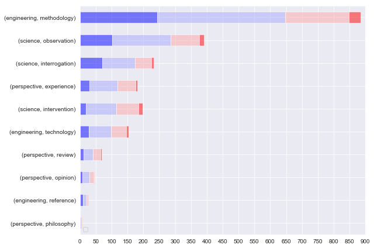

```python
plot_tag_ratings(
    tag_stats(ratings_methodtags, all_levels[:-1], totals=True, rel=False).loc['how'],
    sort_values=True, rel=False, step=50)
```

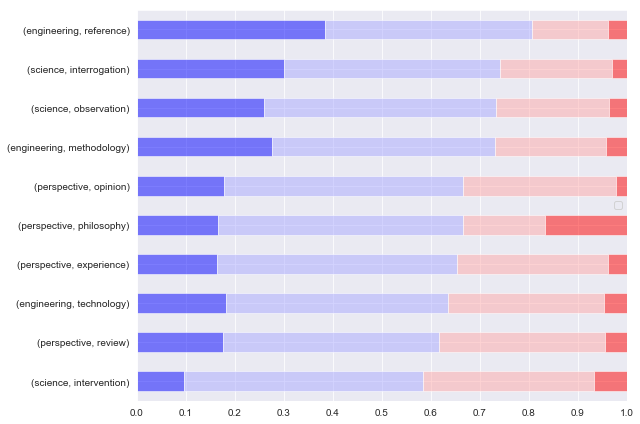

```python
plot_tag_ratings(
    tag_stats(ratings_methodtags, all_levels[:-1], totals=True, rel=True).loc['how'],
    sort_values=True, rel=True)
```

Proposition:

Practitioners favor interrogation and observation research (e.g., surveys and case studies) over intervention research (e.g., experiments).

But:

Experiments are often done with students.

Therefore:

Do practitioners dislike research with students?

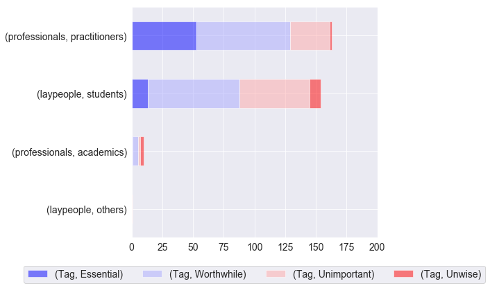

```python
plot_tag_ratings(
    tag_stats(ratings_methodtags, all_levels[:-1], totals=True, rel=False).loc['withwhom'],
    sort_values=True, rel=False)
```

```
rating                       Essential  Worthwhile  Unimportant    Unwise
level_2       level_3
laypeople     others          0.000000    0.000000     1.000000  0.000000
professionals academics       0.100000    0.400000     0.200000  0.300000
laypeople     students        0.084416    0.487013     0.370130  0.058442
professionals practitioners   0.325153    0.466258     0.196319  0.012270
```

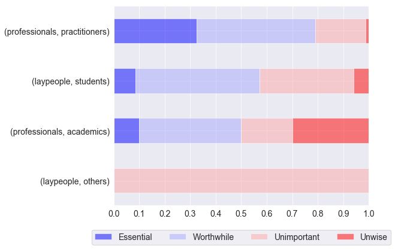

```python
%run setup.py

plot_tag_ratings(
    tag_stats(ratings_methodtags, all_levels[:-1], totals=True, rel=True).loc['withwhom'],
    sort_values=True, rel=True)
plt.savefig("students_vs_professionals.pdf")
```

Proposition:

Highly rated research ideas do *not* involve student participation.

#### Example: Paper Content Tags - Documentation

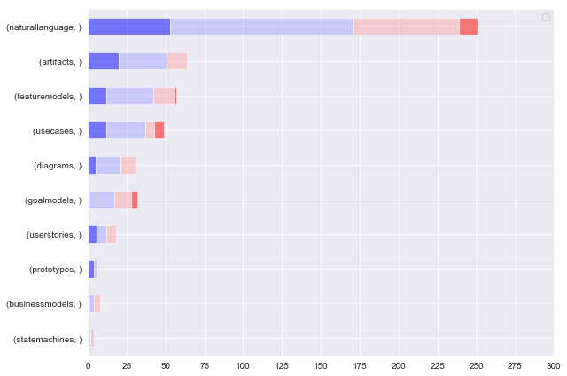

```python
plot_tag_ratings(
    tag_stats(ratings_contenttags, all_levels, totals=True, rel=False).loc[('what','documentation')],
    sort_values=True
)
```

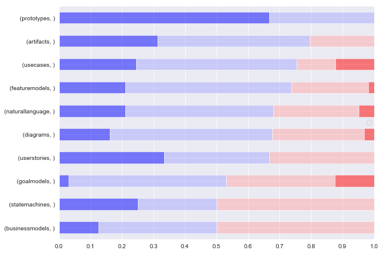

```python
plot_tag_ratings(
    tag_stats(ratings_contenttags, all_levels, totals=True, rel=True).loc[('what','documentation')],
    sort_values=True, rel=True
)
```

Proposition:

Highly rated research ideas do *not* concern goal models.

# What taxonomy

```python
data = dfdict['papertags_what-manual_final']
data.rename(columns={data.columns[0]:'PaperID'}, inplace=True)

reshaped = \
(data.set_index(data.columns.drop('documentation',1).tolist())
   .documentation.str.split(',', expand=True)
   .stack()
   .reset_index()
   .rename(columns={0:'documentation'})
   .loc[:, data.columns]
)

reshaped
```

|  | PaperID | summary | quality | people | process | documentation | SM_first | SM_second | SM_third | phase |
| --- | --- | --- | --- | --- | --- | --- | --- | --- | --- | --- |
| 0 | 1 | A method for automatically recovering software... | traceability | NaN | automation | general | NaN | NaN | NaN | NaN |
| 1 | 4 | An experience report on the development of a m... | NaN | NaN | formalization | general | NaN | NaN | NaN | validation and verification |
| 2 | 5 | A document-driven study on the relevancy of cl... | NaN | NaN | quality assurance | general | NaN | NaN | NaN | NaN |
| 3 | 9 | A tool for automating ambiguity detection and ... | unambiguousness | NaN | automation | natural language | NaN | NaN | NaN | NaN |
| 4 | 11 | A method for developing scenarios at multiple ... | consistency | NaN | NaN | scenarios | NaN | NaN | NaN | validation and verification |
| 5 | 17 | A method for semi-automatically recovering tra... | traceability | NaN | standardization,automation | natural language | NaN | NaN | NaN | NaN |
| 6 | 32 | A document-driven study for refining, assessin... | NaN | NaN | NaN | natural language | NaN | NaN | NaN | NaN |
| 7 | 41 | A method for grading the implementation of use... | NaN | NaN | NaN | use case | quality ====> | usability | NaN | validation and verification |
| 8 | 47 | A method for classifying ambiguities in natura... | unambiguousness | NaN | NaN | natural language | NaN | NaN | NaN | elicitation |
| 9 | 55 | A case study for identifying success factors a... | NaN | NaN | quality assurance | review report | NaN | NaN | NaN | NaN |
| 10 | 56 | A method for extending automated analysis of n... | NaN | NaN | automation | use case | NaN | NaN | NaN | NaN |
| 11 | 56 | A method for extending automated analysis of n... | NaN | NaN | automation | natural language | NaN | NaN | NaN | NaN |
| 12 | 58 | A method for identifying single- and multi-wor... | NaN | NaN | NaN | natural language | NaN | NaN | NaN | NaN |
| 13 | 60 | An experiment with students on the inclusion o... | understandability | NaN | NaN | use case | functional | NaN | NaN | NaN |
| 14 | 61 | A case study for characterizing natural langua... | NaN | NaN | NaN | natural language | NaN | NaN | NaN | validation and verification |
| 15 | 64 | A method for recovering a feature model from t... | NaN | NaN | modeling | feature model | NaN | NaN | NaN | NaN |
| 16 | 65 | A method for performing semi-automated checkin... | completeness,consistency | NaN | automation | natural language | NaN | NaN | NaN | validation and verification |
| 17 | 66 | A solution for automatically linking bug repor... | traceability | NaN | automation | review report | NaN | NaN | NaN | NaN |
| 18 | 68 | A method for supporting use-case analysis that... | NaN | NaN | NaN | use case | NaN | NaN | NaN | NaN |
| 19 | 68 | A method for supporting use-case analysis that... | NaN | NaN | NaN | scenarios | NaN | NaN | NaN | NaN |
| 20 | 69 | A case study for finding out whether a restric... | consistency | NaN | automation | natural language | NaN | NaN | NaN | NaN |
| 21 | 77 | A document-driven study with practitioners and... | completeness,understandability | NaN | NaN | use case | NaN | NaN | NaN | NaN |
| 22 | 77 | A document-driven study with practitioners and... | completeness,understandability | NaN | NaN | other | NaN | NaN | NaN | NaN |
| 23 | 87 | A method for semi-automatic extraction of feat... | NaN | NaN | automation,reuse | feature model | NaN | NaN | NaN | NaN |
| 24 | 87 | A method for semi-automatic extraction of feat... | NaN | NaN | automation,reuse | natural language | NaN | NaN | NaN | NaN |
| 25 | 90 | A method for analyzing cross-references within... | consistency | NaN | NaN | other | quality ====> | other ====> | legal and regulations | validation and verification |
| 26 | 91 | A solution for enabling citizens to report pro... | NaN | NaN | NaN | review report | NaN | NaN | NaN | elicitation |
| 27 | 94 | A solution for extracting logical structures (... | NaN | NaN | automation,modeling | general | NaN | NaN | NaN | management |
| 28 | 97 | A method for simulating quantitative goal mode... | NaN | NaN | NaN | goal model | NaN | NaN | NaN | validation and verification |
| 29 | 106 | A method for automatically constructing models... | NaN | NaN | automation | review report | NaN | NaN | NaN | NaN |
| ... | ... | ... | ... | ... | ... | ... | ... | ... | ... | ... |
| 85 | 337 | A method for semi-automatically translating na... | NaN | NaN | formalization,automation | natural language | NaN | NaN | NaN | validation and verification |
| 86 | 339 | An interview-based study with practitioners fo... | NaN | communication | NaN | general | NaN | NaN | NaN | NaN |
| 87 | 340 | A method for integrating user feedback involvi... | NaN | NaN | NaN | review report | NaN | NaN | NaN | elicitation |
| 88 | 345 | A solution for checking 14 quality criteria in... | NaN | NaN | quality assurance | user story | NaN | NaN | NaN | NaN |
| 89 | 351 | A data-driven study for comparing several prob... | NaN | NaN | automation | review report | NaN | NaN | NaN | NaN |
| 90 | 352 | A document-driven study for understanding and ... | unambiguousness | NaN | NaN | other | NaN | NaN | NaN | elicitation |
| 91 | 355 | A solution for specifying preferences over goa... | NaN | NaN | NaN | natural language | goals | NaN | NaN | NaN |
| 92 | 360 | A case study for investigating which changes r... | NaN | NaN | evolution | use case | NaN | NaN | NaN | NaN |
| 93 | 361 | A solution for calculating how likely a natura... | NaN | NaN | automation | natural language | NaN | NaN | NaN | management |
| 94 | 365 | A document-driven study in the industry on the... | NaN | NaN | NaN | natural language | NaN | NaN | NaN | NaN |
| 95 | 367 | A solution for automatically extracting and tr... | NaN | NaN | automation | natural language | quality ====> | generic | NaN | NaN |
| 96 | 369 | A set of two empirical studies (online survey ... | NaN | NaN | NaN | general | NaN | NaN | NaN | NaN |
| 97 | 377 | A method for automatically identifying the imp... | NaN | NaN | automation | other | architecture | NaN | NaN | management |
| 98 | 385 | A method for integrating goal-oriented require... | NaN | NaN | decision-making,modeling | goal model | goals | NaN | NaN | NaN |
| 99 | 389 | A method for searching certain classes of pote... | completeness,unambiguousness | NaN | NaN | business model | NaN | NaN | NaN | NaN |
| 100 | 394 | A multi-instrument study (survey followed by i... | NaN | NaN | NaN | user story | NaN | NaN | NaN | NaN |
| 101 | 398 | An experiment with students on comparing throu... | NaN | skills | NaN | general | NaN | NaN | NaN | NaN |
| 102 | 402 | A method for revising software requirements sp... | NaN | NaN | quality assurance | general | NaN | NaN | NaN | NaN |
| 103 | 409 | A multi-case study with practitioners on the l... | NaN | NaN | NaN | natural language | NaN | NaN | NaN | documentation |
| 104 | 412 | An interview-based study with practitioners fo... | unambiguousness | communication | NaN | natural language | NaN | NaN | NaN | NaN |
| 105 | 414 | A process for automatically discovering requir... | NaN | NaN | automation | other | NaN | NaN | NaN | elicitation |
| 106 | 415 | A framework for helping analysts in identifyin... | NaN | NaN | formalization | use case | NaN | NaN | NaN | NaN |
| 107 | 417 | A tool for connecting textual notes and video ... | NaN | other | NaN | natural language | NaN | NaN | NaN | elicitation |
| 108 | 417 | A tool for connecting textual notes and video ... | NaN | other | NaN | other | NaN | NaN | NaN | elicitation |
| 109 | 420 | An interview-based study with practitioners fo... | NaN | NaN | NaN | general | NaN | NaN | NaN | documentation |
| 110 | 421 | An experiment with academics for exploring the... | understandability | NaN | NaN | goal model | NaN | NaN | NaN | NaN |
| 111 | 425 | An analysis of the adequacy of different natur... | NaN | NaN | automation | review report | NaN | NaN | NaN | elicitation |
| 112 | 425 | An analysis of the adequacy of different natur... | NaN | NaN | automation | natural language | NaN | NaN | NaN | elicitation |
| 113 | 429 | A method for automatically deriving conceptual... | NaN | NaN | automation,modeling | user story | NaN | NaN | NaN | NaN |
| 114 | 429 | A method for automatically deriving conceptual... | NaN | NaN | automation,modeling | other | NaN | NaN | NaN | NaN |

115 rows × 10 columns

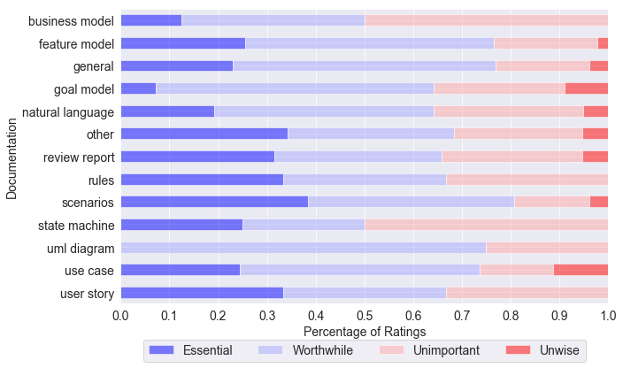

```python
%run setup.py

ratings_with_tags = dfdict['truth_ratings'].merge(reshaped, how='inner')
plot_df(ratings_with_tags, 'documentation', 'Documentation', absolute=False)
plt.rcParams['figure.figsize'] = 9, 9
plt.savefig("content.pdf")
```

```python
dfdict['truth_ratings']
dfdict['papertags_what-manual_final']
```

|  | Unnamed: 0 | summary | quality | people | process | documentation | SM_first | SM_second | SM_third | phase |
| --- | --- | --- | --- | --- | --- | --- | --- | --- | --- | --- |
| 0 | 1 | A method for automatically recovering software... | traceability | NaN | automation | general | NaN | NaN | NaN | NaN |
| 1 | 2 | A set of two techniques for improving the qual... | traceability | NaN | quality assurance | NaN | NaN | NaN | NaN | NaN |
| 2 | 3 | A case study on evaluating a given technique f... | NaN | NaN | prioritization | NaN | NaN | NaN | NaN | elicitation |
| 3 | 4 | An experience report on the development of a m... | NaN | NaN | formalization | general | NaN | NaN | NaN | validation and verification |
| 4 | 5 | A document-driven study on the relevancy of cl... | NaN | NaN | quality assurance | general | NaN | NaN | NaN | NaN |
| 5 | 6 | A case study on the effects of a highly ambigu... | unambiguousness | NaN | NaN | NaN | NaN | NaN | NaN | NaN |
| 6 | 7 | A data-driven study on the importance of quali... | NaN | NaN | NaN | NaN | quality ====> | generic | NaN | NaN |
| 7 | 8 | An interview-based study with practitioners fo... | NaN | NaN | quality assurance | NaN | process | NaN | NaN | validation and verification |
| 8 | 9 | A tool for automating ambiguity detection and ... | unambiguousness | NaN | automation | natural language | NaN | NaN | NaN | NaN |
| 9 | 10 | An experiment with practitioners for evaluatin... | NaN | NaN | evolution | NaN | NaN | NaN | NaN | NaN |
| 10 | 11 | A method for developing scenarios at multiple ... | consistency | NaN | NaN | scenarios | NaN | NaN | NaN | validation and verification |
| 11 | 12 | An industrial evaluation based on benchmarks f... | NaN | NaN | prioritization | NaN | NaN | NaN | NaN | NaN |
| 12 | 13 | A method for reasoning about likely sources of... | uncertainty | NaN | execution | NaN | NaN | NaN | NaN | NaN |
| 13 | 14 | A case study for collecting lessons learned fr... | NaN | NaN | quality assurance | NaN | NaN | NaN | NaN | NaN |
| 14 | 15 | A method for visualizing how cyber-attacks are... | NaN | NaN | visualization | NaN | quality ====> | security | NaN | NaN |
| 15 | 16 | An experiment with students on the effectivene... | NaN | creativity | NaN | NaN | NaN | NaN | NaN | elicitation |
| 16 | 17 | A method for semi-automatically recovering tra... | traceability | NaN | standardization,automation | natural language | NaN | NaN | NaN | NaN |
| 17 | 18 | A case study for validating a multi-level appr... | NaN | NaN | reuse | NaN | NaN | NaN | NaN | management |
| 18 | 19 | A method for using low-effort ad-hoc videos as... | understandability | NaN | visualization | NaN | NaN | NaN | NaN | NaN |
| 19 | 20 | A method for building domain ontologies suitab... | understandability | subjectivity | NaN | NaN | NaN | NaN | NaN | elicitation |
| 20 | 21 | An interview-based study for explaining the ca... | NaN | NaN | quality assurance | NaN | process | NaN | NaN | NaN |
| 21 | 22 | An analysis on the integration of non-function... | NaN | NaN | modeling | NaN | quality ====> | generic | NaN | NaN |
| 22 | 23 | A method for systematically and repeatedly exc... | NaN | collaboration | NaN | NaN | NaN | NaN | NaN | NaN |
| 23 | 24 | A method for formally representing requirement... | NaN | NaN | formalization | NaN | tests | NaN | NaN | validation and verification |
| 24 | 25 | A multi-case study on agile prioritization and... | NaN | NaN | prioritization | NaN | NaN | NaN | NaN | NaN |
| 25 | 26 | A process for creating traceability links betw... | traceability | NaN | quality assurance | NaN | quality ====> | other ====> | safety | NaN |
| 26 | 27 | A method for assessing the completeness of spe... | completeness | subjectivity | quality assurance | NaN | NaN | NaN | NaN | NaN |
| 27 | 28 | An experience report on the value provided by ... | traceability | NaN | NaN | NaN | NaN | NaN | NaN | NaN |
| 28 | 29 | An experience report on the development of a s... | NaN | communication | modeling | NaN | NaN | NaN | NaN | NaN |
| 29 | 30 | An experience report on modeling a safety crit... | NaN | NaN | formalization | NaN | quality ====> | other ====> | safety | NaN |
| ... | ... | ... | ... | ... | ... | ... | ... | ... | ... | ... |
| 405 | 406 | A training program for assisting requirement a... | NaN | skills | NaN | NaN | NaN | NaN | NaN | NaN |
| 406 | 407 | An ontology for describing properties of data ... | NaN | NaN | NaN | NaN | quality ====> | other ====> | privacy | NaN |
| 407 | 408 | An experience report on applying a tailored IN... | NaN | NaN | NaN | NaN | process | NaN | NaN | NaN |
| 408 | 409 | A multi-case study with practitioners on the l... | NaN | NaN | NaN | natural language | NaN | NaN | NaN | documentation |
| 409 | 410 | A method for specifying changes in intentions ... | NaN | NaN | decision-making,evolution | NaN | NaN | NaN | NaN | NaN |
| 410 | 411 | An online survey on the ability of laypersons,... | NaN | skills | NaN | NaN | quality ====> | other ====> | legal and regulations | NaN |
| 411 | 412 | An interview-based study with practitioners fo... | unambiguousness | communication | NaN | natural language | NaN | NaN | NaN | NaN |
| 412 | 413 | A study based on case studies and interviews w... | traceability | collaboration | NaN | NaN | NaN | NaN | NaN | management |
| 413 | 414 | A process for automatically discovering requir... | NaN | NaN | automation | other | NaN | NaN | NaN | elicitation |
| 414 | 415 | A framework for helping analysts in identifyin... | NaN | NaN | formalization | use case | NaN | NaN | NaN | NaN |
| 415 | 416 | A framework for specifying performance require... | completeness | NaN | reuse | NaN | quality ====> | performance efficiency | NaN | documentation |
| 416 | 417 | A tool for connecting textual notes and video ... | NaN | other | NaN | natural language,other | NaN | NaN | NaN | elicitation |
| 417 | 418 | A literature review on the existing approaches... | NaN | NaN | NaN | NaN | goals | NaN | NaN | NaN |
| 418 | 419 | An experiment with students for validating tha... | NaN | NaN | modeling | NaN | NaN | NaN | NaN | NaN |
| 419 | 420 | An interview-based study with practitioners fo... | NaN | NaN | NaN | general | NaN | NaN | NaN | documentation |
| 420 | 421 | An experiment with academics for exploring the... | understandability | NaN | NaN | goal model | NaN | NaN | NaN | NaN |
| 421 | 422 | A data-driven study for understanding the comm... | NaN | communication | evolution | NaN | NaN | NaN | NaN | NaN |
| 422 | 423 | A method for eliciting security requirements r... | NaN | NaN | NaN | NaN | quality ====> | security | NaN | elicitation |
| 423 | 424 | An interview-based study with practitioners on... | traceability | NaN | NaN | NaN | NaN | NaN | NaN | documentation |
| 424 | 425 | An analysis of the adequacy of different natur... | NaN | NaN | automation | review report,natural language | NaN | NaN | NaN | elicitation |
| 425 | 426 | A model for understanding the implications of ... | unambiguousness | NaN | NaN | NaN | quality ====> | other ====> | privacy | NaN |
| 426 | 427 | A literature review on the existing approaches... | NaN | NaN | visualization | NaN | NaN | NaN | NaN | NaN |
| 427 | 428 | A case study on generating and rating ideas fr... | NaN | creativity,skills | NaN | NaN | NaN | NaN | NaN | elicitation |
| 428 | 429 | A method for automatically deriving conceptual... | NaN | NaN | automation,modeling | user story,other | NaN | NaN | NaN | NaN |
| 429 | 430 | A method for enlarging traditional traceabilit... | traceability | NaN | NaN | NaN | NaN | NaN | NaN | NaN |
| 430 | 431 | A case study on the need for requirement chang... | NaN | NaN | evolution | NaN | NaN | NaN | NaN | management |
| 431 | 432 | A taxonomy for classifying requirement errors ... | NaN | NaN | quality assurance | NaN | NaN | NaN | NaN | NaN |
| 432 | 433 | A data-driven study for understanding the effe... | understandability | NaN | modeling | NaN | NaN | NaN | NaN | NaN |
| 433 | 434 | An experiment with students for investigating ... | NaN | skills | quality assurance | NaN | NaN | NaN | NaN | NaN |
| 434 | 435 | A framework for supporting a systematic and co... | NaN | NaN | NaN | NaN | goals,quality ====> | security | NaN | elicitation |

435 rows × 10 columns

### Ratings Grouped by Paper and Respondent Tags

- Useful to answer, e.g., RQ5: Do practitioners’ perceptions and views differ in dependence on their roles?
- Some interesting propositions derivable, e.g., regarding research on human factors in RE:
  - Of all prominent roles, testers exhibit the strongest interest in research on collaboration.
  - Of all prominent roles, developers are least interested in research on communication.
  - Business analysts and project managers find research on communication particularly essential.
- But: Results are based on "small n"...

## 3. Discussion

[figure not shown]

## Thank You!

[figure not shown]